# Part II - (Ford GoBike System Data ExplANation 2025)

## Investigation Overview

> 1. Trip Count and User Base:
> - Subscribers significantly outnumber customers in trip count across all days, underscoring their reliance on the service for frequent, routine travel, such as commuting.
> - Despite lower trip counts, customers spend more time on trips compared to subscribers, hinting at less routine and more recreational trip purposes.
> 2. Trip Duration and Patterns:
> - Customers consistently exhibit higher average trip durations compared to subscribers, regardless of the day.
> - Customer durations peak on weekends (Saturday and Sunday), suggesting usage is largely driven by leisure activities.
> - Subscribers maintain stable trip durations throughout the week, reflecting routine and predictable usage.
> 3. Purpose of Trips:
> - Subscriber trips are characterized by frequent, shorter journeys focusing on efficiency and routine needs.
> - Customer trips are fewer but longer, with a clear focus on leisure or occasional use, such as recreational outings or tourism.
> 4. Distance and Weekend Trends:
> - Customer trips are notably longer in both duration and distance compared to those of subscribers across all days of the week.
> - Both groups show longer durations for shorter distances on weekends compared to weekdays, reinforcing the idea that weekends are primarily for leisure use.

## Dataset Overview and Executive Summary

> This dataset contains information about bike-sharing system rides, specifically from February 2019. It includes details about users, such as age and gender, along with trip data such as the start and end points, stations, and trip durations. Additionally, it captures information on the type of user (customer or Subscriber).

```python
# import all packages and set plots to be embedded inline
import numpy as np
import pandas as pd
import matplotlib.pyplot as plt
import seaborn as sns

sns.set_style('darkgrid')

# suppress warnings from final output
import warnings
warnings.simplefilter("ignore")
```

```python
# load in the dataset into a pandas dataframe
df= pd.read_csv('cleaned-201902-fordgobike-tripdata.csv')
df.head()
```

|  | Unnamed: 0 | duration_sec | start_station_id | start_station_name | end_station_id | end_station_name | bike_id | user_type | gender | bike_share_for_all_trip | ... | day_sequence | end_hour | duration_minutes | duration_hours | distance | speed | age | weekend_or_working | grouped_categories | same_station |
| --- | --- | --- | --- | --- | --- | --- | --- | --- | --- | --- | --- | --- | --- | --- | --- | --- | --- | --- | --- | --- | --- |
| 0 | 0 | 52185 | 21 | Montgomery St BART Station (Market St at 2nd St) | 13 | Commercial St at Montgomery St | 4902 | Customer | Male | No | ... | Afternoon | 8 | 869.75 | 14.50 | 0.544709 | 0.010438 | 41 | Working | Male \| Customer \| No | False |
| 1 | 2 | 61854 | 86 | Market St at Dolores St | 3 | Powell St BART Station (Market St at 4th St) | 5905 | Customer | Male | No | ... | Afternoon | 5 | 1030.90 | 17.18 | 2.704545 | 0.043725 | 53 | Working | Male \| Customer \| No | False |
| 2 | 4 | 1585 | 7 | Frank H Ogawa Plaza | 222 | 10th Ave at E 15th St | 4898 | Subscriber | Male | Yes | ... | Night | 0 | 26.42 | 0.44 | 2.409301 | 1.520064 | 51 | Working | Male \| Subscriber \| Yes | False |
| 3 | 5 | 1793 | 93 | 4th St at Mission Bay Blvd S | 323 | Broadway at Kearny | 5200 | Subscriber | Male | No | ... | Night | 0 | 29.88 | 0.50 | 3.332203 | 1.858451 | 66 | Working | Male \| Subscriber \| No | False |
| 4 | 6 | 1147 | 300 | Palm St at Willow St | 312 | San Jose Diridon Station | 3803 | Subscriber | Female | No | ... | Night | 0 | 19.12 | 0.32 | 2.028551 | 1.768571 | 42 | Working | Female \| Subscriber \| No | False |

5 rows × 23 columns

```python
df.shape
```

```
(171230, 23)
```

```python
ordered_days = ['Monday', 'Tuesday', 'Wednesday', 'Thursday', 'Friday', 'Saturday', 'Sunday']
```

```python
def user_type_plot(bi_var=None,multi_var=None):
    plt.figure(figsize=(10,5))
    user_type_color={'Customer': sns.color_palette('dark:#5A9_r')[0], 'Subscriber':sns.color_palette('dark:#5A9_r')[2]}
    if bi_var:
        sns.countplot(data=df, x='start_weekday', hue='user_type', order=ordered_days, palette=user_type_color)
        title='Distribution'
    elif multi_var:
        sns.barplot(data = df, x = 'start_weekday', y = 'duration_minutes', hue = 'user_type', order=ordered_days, palette=user_type_color)
        plt.ylabel('Duration (minutes)')
        title='Trip Duration'

    plt.title(f'{title} of Customers and Subscribers Throughout the Week')
    plt.legend(loc = 0, ncol = 3, framealpha = 1, title = 'User Type')
    plt.xlabel('')
```

## (Visualization 1)

> This visualization shows the differences in the distribution of Customers and Subscribers in bike share usage throughout the week.

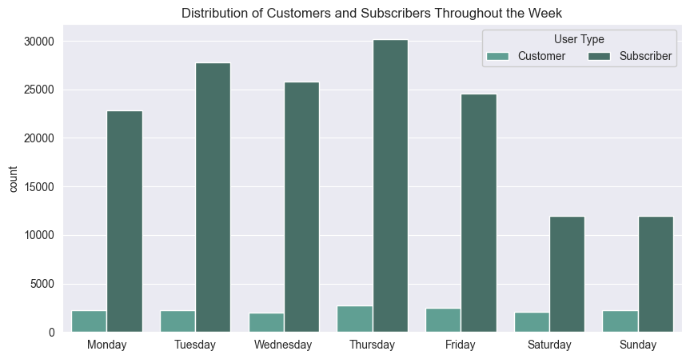

```python
user_type_plot(bi_var=True)
```

> The number of subscribers significantly outweighs the number of customers on all days of the week.

> Subscriber activity peaks on Thursday and decreases on weekends, indicating that their usage is likely tied to workday commuting.

## (Visualization 2)

> This visualization shows the differences in trip durations between Customers and Subscribers throughout the week.

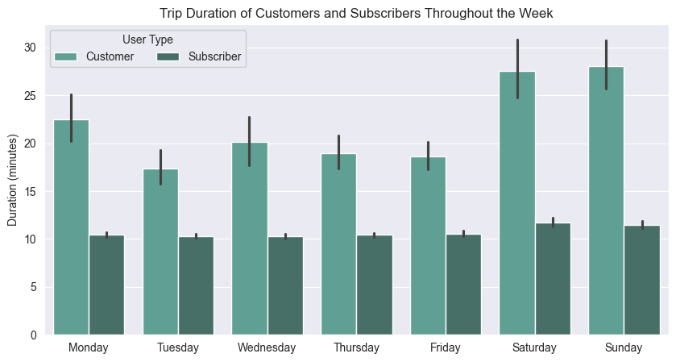

```python
user_type_plot(multi_var=True)
```

> Customers consistently have higher average trip durations compared to subscribers across all days of the week.

> Customer durations peak on weekends (Saturday and Sunday), likely due to leisure activities.

> Subscribers maintain a relatively stable duration throughout the week, while customers show notable variation.

## (Visualization 3)

> This visualization shows the differences in bike share usage, including duration and distance traveled, between Customers and Subscribers across the week.

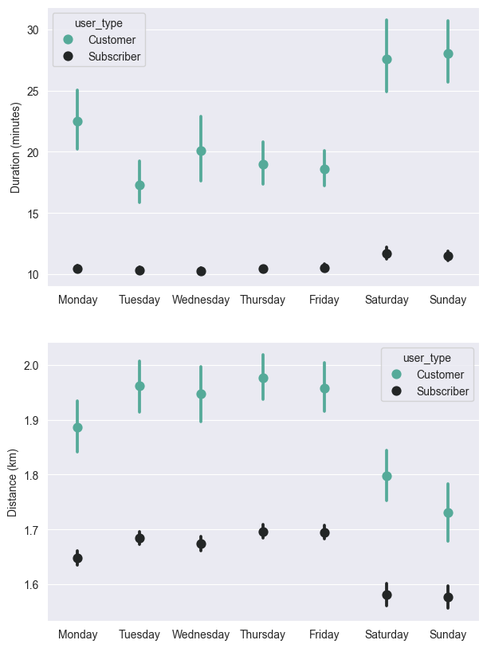

```python
plt.figure(figsize=(7, 10))

# Create subplots
plt.subplot(2, 1, 1)
ax1 = sns.pointplot(data=df, x='start_weekday', y='duration_minutes', hue='user_type',
                    palette='dark:#5A9_r',linestyles='', order=ordered_days)
ax1.set_xlabel('')
ax1.set_ylabel('Duration (minutes)')

plt.subplot(2, 1, 2)
ax2 = sns.pointplot(data=df, x='start_weekday', y='distance', hue='user_type',
                    palette='dark:#5A9_r',linestyles='', order=ordered_days)
ax2.set_xlabel('')
ax2.set_ylabel('Distance (km)');
```

> Customers' trips are significantly longer in both distance and duration compared to subscribers' trips, regardless of the day of the week.

> For both customers and subscribers, trips tend to last longer but cover shorter distances on weekends compared to weekdays. This pattern suggests that, on weekends, most people use the bikes primarily for leisure activities.

## Conclusion

> The analysis highlights distinct usage behaviors between customers and subscribers. Subscribers prioritize volume and efficiency with short, frequent trips, often for commuting. In contrast, customers focus on leisure with fewer but longer trips, primarily during weekends.